# Titanic Exploratoin

### 2. The distribution of the Parch (number of parents/children aboard) among passengers on the Titanic

#### Did not survive (“0”)

- Median parch: The median number of parents/children aboard for non-survivors is 0.
- Interquartile Range (IQR) : The IQR spans from 0 to 0, indicating that the middle 50% of non-survivors had no parents or children aboard.
- Outliers : There are several outliers above the upper whisker, indicating passengers with higher numbers of parents/children aboard who did not survive. These outliers range up to 6.

#### Survived (“1”)

- Median parch : The median number of parents/children aboard for survivors is also 0.
- Interquartile range (IQR) : The IQR extends from 0 to 1, showing that the middle 50% of survivors had between 0 and 1 parents or children aboard.
- Outliers : There are outliers above the upper whisker, indicating passengers with higher numbers of parents/children aboard who survived. These outliers range from 3 up to 5.

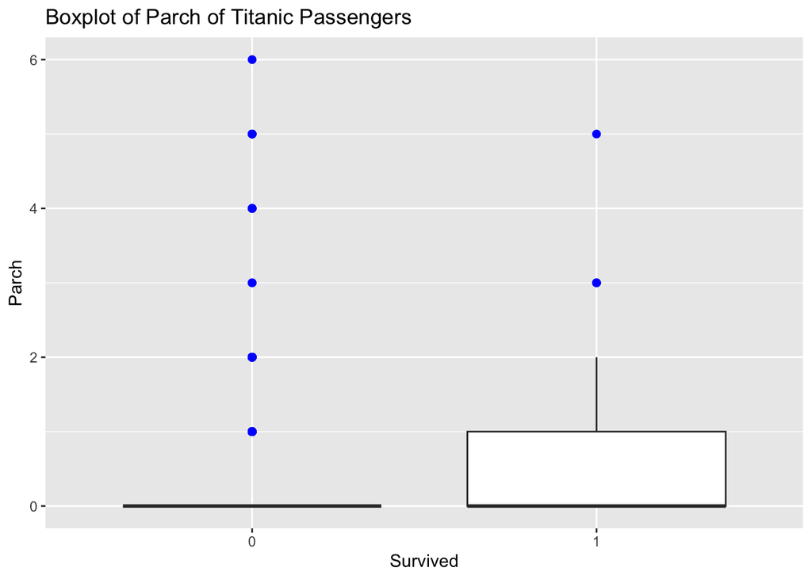

```r
library(ggplot2)
ggplot(titanic_data, aes(x = as.factor(Survived), y = Parch)) +
  geom_boxplot(outlier.colour = "blue", outlier.shape = 20, outlier.size = 3) +
  labs(title = "Boxplot of Parch of Titanic Passengers", x = "Survived", y = "Parch")
```

### 3. The distribution of the Fare (the fare paid by passengers) among passengers on the Titanic

#### Did not survive (“0”)

- Median fare : The median fare for non-survivors is relatively low.
- Interquartile Range (IQR) : The IQR spans from a low fare to a moderate fare, indicating that the middle 50% of non-survivors paid relatively low fares.
- Outliers : There are several outliers above the upper whisker, indicating that some non-survivors paid significantly higher fares.

#### Survived (“1”)

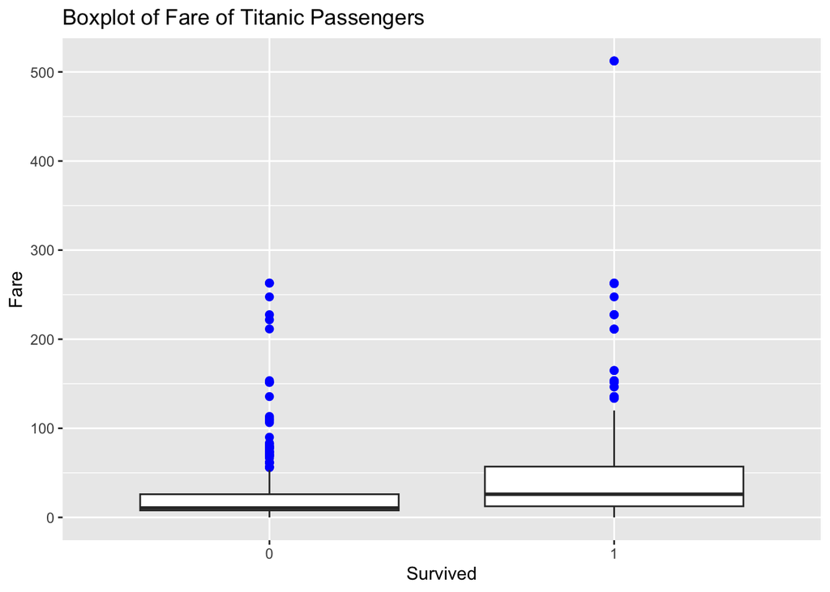

```r
library(ggplot2)
ggplot(titanic_data, aes(x = as.factor(Survived), y = Fare)) +
  geom_boxplot(outlier.colour = "blue", outlier.shape = 20, outlier.size = 3) +
  labs(title = "Boxplot of Fare of Titanic Passengers", x = "Survived", y = "Fare")
```